# IndexNumber: An R Package for Measuring the Evolution of Magnitudes

Alejandro Saavedra-Nieves

Universidade de Santiago de Compostela

Paula Saavedra-Nieves

Universidade de Santiago de Compostela

2021-06-07

Abstract

Index numbers are descriptive statistical measures useful in economic settings for comparing simple and complex magnitudes registered, usually in two time periods. Although this theory has a large history, it still plays an important role in modern today’s societies where big amounts of economic data are available and need to be analyzed. After a detailed revision on classical index numbers in literature, this paper is focused on the description of the R package [*IndexNumber*](https://CRAN.R-project.org/package=IndexNumber) with strong capabilities for calculating them. Two of the four real data sets contained in this library are used for illustrating the determination of the index numbers in this work. Graphical tools are also implemented in order to show the time evolution of considered magnitudes simplifying the interpretation of the results.

# Introduction

The problem of reducing a large amount of available microeconomic data is common in dynamic and modern economies. Individuals of today’s societies consume services of hundred of commodities over a year, and most producers use and produce hundreds of individual products and services. This overwhelming abundance of data is usually summarized through index numbers theory. *Index numbers* are descriptive statistical measures useful in order to compare or measure changes in simple and complex magnitudes over time. The goal is usually to determine possible increases or decreases and, more generally, trend changes. The situations to be compared are in no way restricted; they may be two time periods (hours, days, months, or years); two places (two cities or countries); or two groups of people (economically active and inactive population). For simplicity in the exposition, we refer to temporal index numbers in this paper. The rest of the situations mentioned could be considered modifying the notation slightly.

Although index numbers are considered a classical statistical tool, the problem of how to construct them is as much one of economic theory as of statistical technique, see (Frisch 1936). This can be checked by analyzing their considerable history. Initial works involving index numbers date back to the early 18th century. During the creation of a college in 1440–1460, it was stipulated that any member had to leave it if his richness exceeded five pounds per year. The Anglican Bishop Fleetwood desired to know if, according to the price evolution, this promise could be kept three centuries later. Then, he studied the evolution of prices corresponding to four products (wheat, meat, drink, and clothing) from 1440 to 1700. He concluded that five pounds in 1440–1460 had the same value as 30 pounds in 1700. More details can be found in (Fleetwood 1707). (Dûtot 1754) studied the diminution of the money value analyzing the incomes of kings Louis XII and Louis XV. In order to know which of them had the largest disposable income, he considered the prices of several goods of different nature as such as a chicken, a rabbit, a pigeon, or the day’s work value. From the discovery of the Americas, the astronomy professor of Padoue analyzed the evolution of prices in 1764. He considered the prices of three commodities (grains, wine, and cooking oil), and he studied their variation from 1500 to 1750. (Evelyn 1798) can be seen as a precursor of index numbers establishing a price index number from 1050 to 1800. In this work, notions as the year of reference and relative prices were introduced. According to (M. G. Kendall 1977), the real father of index numbers is Joseph Lowe. Many problems dealing with their construction were presented in (Lowe 1822). In fact, Lowe’s measurement would be known as the Laspeyres index later. In the second half of the 19th century, statisticians developed many advances in this setting. (William Stanley Jevons 1863) recommended considering the geometrical mean in order to construct an index number. Between 1864 and 1880, (E. Laspeyres 1864; K. Laspeyres 1871), (Drobisch 1871), and (Paasche 1874) worked on the evolution of prices for material goods from the approach of weighted index numbers. (Palgrave 1886) proposed to weigh the relative prices by the total amount of the considered good. (Fisher 1922) defined a new index number calculated as the geometric mean of the Laspeyres and the Paasche index numbers. In the same period, Marshall and Edgeworth proposed to calculate weighted means. For an in-depth review on this topic, see (M. Kendall 1969), (Allen 1982) or more recently, (CPIManual 2004), or (Dodge 2008).

Nowadays, economists continue to use index numbers to make comparisons over time despite their long background. In fact, the main applications of index numbers are either economic, or they occur in related fields as demography or technology. In such settings, the magnitudes to be compared through index numbers usually come in pairs, one of price and the other a matching one of quantity. This pair may be designed to account for the variation in an aggregate value, as when movements in the aggregated expenditure of consumers are analyzed into the two components of changes in prices and in real consumption. Some more recent contributions in index numbers theory are exposed next. (Barnett 1980) focused on economic monetary aggregates from this approach. Changes in food prices were analyzed in (Lamm 1980). Index numbers in chain, or more commonly chain indices, are considered in (Forsyth and Fowler 1981). (Boyle 1988) analyzed the volume of Irish agricultural output from 1960 to 1982. Scanner data on coffee sales are studied in (Haan and Opperdoes 1997). (Hill 1999) shows how a comparison of price levels across a group of countries can be made by chaining Fisher index numbers across a spanning tree. Inequality and poverty in several regions of Thailand are studied through the construction of urban and rural cost of living and welfare indices in (Kakwani and Hill 2002). (Dumagan 2002) showed that the Fisher index could be numerically approximated by other superlative index numbers. In (Reinsdorf, Diewert, and Ehemann 2002), additive decompositions of the Fisher index are derived in order to know how much each item contributes to its overall change. From data from United States, Canada, France, Germany, Italy, Japan, and the United Kingdom, drug price and quantity index numbers are considered in (Danzon and Chao 2000). (Ang, Liu, and Chung 2004) used a generalized version of the Fisher index to analyze CO$_2$ emission. In (Boyd and Roop 2004), the structural change in energy intensity is studied. Exploring the duality between a return to dollar definition of profit and the generalized distance function, the relationship between the Laspeyres, Paasche and Fisher productivity index numbers is established in (Zofı́o and Prieto 2006). (Hill 2006) showed an illustration on index numbers also using scanner data. An application to major crops in Manitoba is presented in (Coyle 2007). According to (Diewert and Nakamura 2007), Paasche, Laspeyres, or Fisher index number formula is useful in order to manage the total factor productivity growth. The importance of the hedonic imputation method in price index numbers is analyzed in (Hill and Melser 2008) from a data set containing house prices for three regions in Sydney over a three years period. The impact of time aggregation on price change estimates for several supermarket item categories is considered in (Ivancic, Diewert, and Fox 2011). (Białek 2012) proposed a general price index formula with the Fisher, Laspeyres, and Paasche indices as its particular cases. (Białek 2014) presented an original price index, and its performance is analyzed through a simulation study where it is compared to several classical price index numbers. A generalized version of the Fisher index is considered in (Su and Ang 2014) in order to analyze changes in the carbon emissions embodied in China’s exports. (O’Donnell 2018) analyzed the productivity change defined as measures of output quantity change divided by measures of input quantity change. (Zhen et al. 2019) constructed panel price index numbers using retail scanner data in order to compare consumption costs across space and time.

This paper is focused on the description of the R package [*IndexNumber*](https://CRAN.R-project.org/package=IndexNumber) (Saavedra-Nieves and Saavedra-Nieves 2021), available from the *Comprehensive R Archive Network* at https://CRAN.R-project.org/package=IndexNumber, and its capabilities for calculating classical index numbers. It is organized as follows. Index numbers are formally defined in Section 2. Section 2.1 introduces simple index numbers. Concretely, simple index numbers in series and in chain are distinguished. In Section 2.2, non-weighted and weighted complex index numbers are presented. Details on the usage of *IndexNumber* package are considered from Section 3. The four real data sets contained in the library are also described briefly. Note that two of them are used in this paper in order to illustrate the calculation of index numbers. They are available on the website of the *Spanish Statistical Office (INE)*, http://www.ine.es.

# Preliminaries on index numbers

*Index numbers* are statistical measures that are useful to compare single and multiple magnitudes for the same interval of time. In both cases, this comparison is made with respect to an element of the mentioned series that is called base period or reference. Some examples of simple magnitudes are prices of a good, sold amounts of a product, or other general individual values. However, most of the time, comparing these simple quantities has not practical interest. If the goal is to analyze some real phenomena where many variables are involved, complex indices must be considered. Using these ideas, index numbers are usually classified into the following two groups:

- An index number is said to be simple if it corresponds to the ratio of two values of the same variable, measured in two different instants. Therefore, a *simple index number* provides the variation that the single magnitude has suffered between two different time periods. For instance, a simple index number of the price will give the relative variation of the price between the current period and the period taken as reference.
- Most of the time, comparing prices, amounts, or values of a single product individually is not of interest in practice. If the goal is to analyze some real situations where different variables have influence, a *complex number index* has to be considered. It globally summarizes the information of the different magnitudes involved in the problem. For instance, the evolution cost of life in a country is a common case where it is necessary to select a set of goods or variables that give information about it. The relative importance of each of the goods considered must be measured and taken into account.

A wider overview of both classes of index numbers is included in the next sections. In particular, we distinguish the different subclasses belonging to each of them and their possible relationships.

## Simple index numbers

A *simple index number* is a statistical indicator of the percentage of variation of a single magnitude in two different instants. Simple index numbers are usually classified according to the element that we take as reference. In particular, we distinguish two types of simple index numbers. First, we describe simple index numbers in series, when the first value of the series is taken as the reference value, and simple index numbers in chain (or chain indices), when the reference is the immediately previous value in the serie.

In what follows, we assume that $X=\{x_0,x_1,\dots,x_T\}$ denotes the observations of the magnitude $X$ for the $T+1$ time instants considered. Besides, $x_0$ is usually taken as the base period. Most common simple index numbers are individually referred to variables in real-world situations as the followings:

- the *price of a good*, denoted by $p$;
- the *amount of produced or sold product*, denoted by $q$; or
- the *value of a good*, denoted by $v$. This value is usually obtained as the product of the price and the amount variables.

In this section, we illustrate the usage of simple index numbers on a real example. Table 1 shows the number (thousands) of economically active women and men in Spain from the first trimester of 2002 (taken as a reference value). Remark that four trimesters of each year are denoted by T1, T2, T3 and T4, respectively.

Table 1: Number (thousands) of economically active women and men in Spain from first trimester of 2002.

| Stages | 2002 (T1) | 2002 (T2) | 2002 (T3) | 2002 (T4) | 2003 (T1) | 2003 (T2) | ... |
| --- | --- | --- | --- | --- | --- | --- | --- |
| Total of women | 7442.70 | 7580.80 | 7670.20 | 7751.50 | 7868.70 | 7977.80 | ... |
| Total of men | 11192.30 | 11289.40 | 11445.10 | 11472.80 | 11552.50 | 11661.40 | ... |

This dataset, included in *IndexNumber* package, can be obtained from the Economically Active Population Survey (EPA) elaborated by the Spanish Statistics National Institute (INE).

### Simple index numbers in series

Let $x_0$ and $x_t$ be the values of the variable $X$ where $x_0$ corresponds to the base period and $t\in \{0,1,\dots,T\}$, respectively. Thus, the value of the simple index number in series for $X$ in $t$ is defined as follows:
$$\label{niinserie}
I_0^t(X)=\frac{x_t}{x_0}\cdot 100. (\#eq:niinserie)$$
For each $t\in \{0,1,\dots,T\}$, this measure has a natural interpretation. Fixed a certain variable of interest $X$, the index number in series in $t$ shows the percentage of variation of the magnitude in this instant of time with respect to the reference value (in this case, the initial one).

Using this type of index number, some usual magnitudes can be formally defined as it is indicated next:

- When prices are considered, the *relative price* of a product $i$, also called simple price index, can be determined as
  $$p_0^t=\frac{p_{it}}{p_{i0}},$$
  where $p_{it}$ denotes the price at instant $t$ and $p_{i0}$, the price in the base period.
- The *relative amount* of a product $i$ can be written as
  $$q_0^t=\frac{q_{it}}{q_{i0}},$$
  where $q_{it}$ denotes the produced or sold amount at instant $t$ and $q_{i0}$, the amount for the base period.
- Finally, the *relative value* of a product $i$ has the next expression:
  $$v_0^t=\frac{v_t}{v_0}=\frac{p_{it}q_{it}}{p_{i0}q_{i0}}\cdot
  100= p_0^t\cdot q_0^t\cdot 100,$$
  where $v_{t}$ denotes the value of the good at instant $t$ and $v_{0}$, the value of the base period.

Below, we illustrate the usage of simple index numbers on the two series included in Table 1. Thus, the simple index numbers in series for the economically active women and men in Spain from the first trimester of 2002 is given in Table 2.

Table 2: Simple index numbers in series for number (thousands) of economically active women and men in Spain from the first trimester of 2002.

| Stages | 2002 (T1) | 2002 (T2) | 2002 (T3) | 2002 (T4) | 2003 (T1) | 2003 (T2) | ... |
| --- | --- | --- | --- | --- | --- | --- | --- |
| Index number for women | 100.00 | 101.86 | 103.06 | 104.15 | 105.73 | 107.19 | ... |
| Index number for men | 100.00 | 100.87 | 102.26 | 102.51 | 103.22 | 104.19 | ... |

Comparing the evolution of the index numbers in series for the population of women and men shown in Table 2 has an interest, for instance, to analyze the effect of variable sex in the Spanish labor market. Note that the number of economically active women and men in the second trimester of 2003 is 7.2% and 4.2% larger than in the reference time, respectively. Therefore, women increasing is slightly larger than men.

### Simple index numbers in chain

Below, we introduce another approach of simple index numbers. Contrary to our previous assumptions, this new setting arises when the reference value is not the initial one; rather we take the value immediately preceding. Let $x_{t}$ and $x_{t-1}$ be two values of a variable $X$ observed in two consecutive instants $t$ and $t-1$, being $t\in \{1,2,\dots,T\}$. Thus, the value of the *index number in chain* or *chain index* (cf. (Forsyth and Fowler 1981)) that corresponds to an instant $t$, with $t\in \{1,2,\dots,T\}$, is defined as follows:
$$\label{niinchain}
IC^t(X)=\frac{x_t}{x_{t-1}}\cdot 100. (\#eq:niinchain)$$
Again, this index number can be naturally interpreted. It is worth mentioning that these measures the variation of the characteristic under study with respect to the previous value in a fixed instant $t$. For instance, these index numbers reflect the percentage variation that the variable experiments between two consecutive values in time series settings.

To illustrate this definition, we take again the example considered in the previous section. For this subset of values, we obtain again the evolution of the amount of economically active people (per sex) in Spain under this new approach.

Table 3: Simple index numbers in chain for number (thousands) of economically active women and men in Spain from the first trimester of 2002.

| Stages | 2002 (T1) | 2002 (T2) | 2002 (T3) | 2002 (T4) | 2003 (T1) | 2003 (T2) | ... |
| --- | --- | --- | --- | --- | --- | --- | --- |
| Index number for women | 100.00 | 101.86 | 101.18 | 101.06 | 101.51 | 101.39 | ... |
| Index number for men | 100.00 | 100.87 | 101.38 | 100.24 | 100.70 | 100.94 | ... |

Table 3 shows the evolution in time of the number (thousands) of economically active women and men in Spain from the trimester of 2002 (see Table 1). According to the obtained results, we emphasize as relevant that the number of economically active women and men in the second trimester of 2003 increases 1.4% and 0.9%, respectively, with respect to the previous trimester.

**Relationship between simple index numbers in series and in chain**

This section briefly introduces some comments on the relations between simple index numbers in series and in chain. In this way, one can be obtained from another (and vice versa) without having to use the exact values of the magnitude under study.

Take $x_t$ the value of the variable $X$ in instant $t$, with $t\in \{1,2,\dots,T\}$. Thus, a simple index in chain can be obtained from a simple index in series due to the relation
$$IC^t(X)=\frac{x_t}{x_{t-1}}\cdot 100=
\frac{\frac{x_t}{x_0}}{\frac{x_{t-1}}{x_0}}\cdot
100=\frac{I_0^t(X)}{I_0^{t-1}(X)}\cdot 100.$$
For example, from simple index numbers in series for women shown in Table 2, it is possible to obtain the corresponding simple index number in chain for women also for the first trimester of 2003 (contained in Table 3). That is,
$$IC^{2003(T1)}(X)=\frac{7868.70}{7751.50}\cdot
100=\frac{105.72}{104.15}\cdot 100=101.51.$$

Besides, simple indices in series can be equivalently obtained for each $t\in \{1,\dots,T\}$ from indices in chain:
$$I_0^t(X)=\frac{x_t}{x_{0}}\cdot
100=\frac{x_t}{x_{t-1}}\frac{x_{t-1}}{x_{t-2}}\cdots \frac{x_2}{x_{1}}\frac{x_1}{x_{0}}
\cdot 100=\frac{IC^t(X)}{100}\cdot\frac{IC^{t-1}(X)}{100}\cdot \cdots
\cdot \frac{IC^{2}(X)}{100}\cdot \frac{IC^{1}(X)}{100}\cdot
100.$$
For instance, if we consider the simple index numbers in chain shown in Table 3, it is possible to obtain the simple index number in series for the first trimester of 2003 contained in Table 2. That is, we check that
$$I_0^{2003(T1)}(X)= \frac{100.70}{100} \cdot
\frac{100.24}{100} \cdot \frac{101.38}{100} \cdot
\frac{100.87}{100} \cdot 100.$$

**Variation Rate**

In this section, we formally introduce another measure of the evolution of a magnitude. Furthermore, we relate it to the simple index numbers previously defined.

The *variation rate* of the observations in the instants $t$ and $t-1$, with $t\in \{1,\dots,T\}$, is denoted by $Rate^t(X)$ for each $t\in\{1,\dots,T\}$. It can be calculated from the simple index in chain as follows:
$$Rate^{t}(X)=\frac{x_{t}-x_{t-1}}{x_{t-1}}\cdot100=IC^t(X)\cdot
100.$$
This definition can be extended to any pair of instants in $\{0,1,2,\dots,T\}$. Take $t_1, t_2\in \{0,1,2,\dots,T\}$ such that $t_1<t_2$. Let $x_{t_1}$ be the value of a variable measure in instant $t_1$ and let $x_{t_2}$ be the value of a variable measure in a later instant $t_2$. Formally, the *variation rate* of $X$ in $t_2$ with respect to $t_1$ is
$$Rate_{t_1}^{t_2}(X)=\frac{x_{t_2}-x_{t_1}}{x_{t_1}}\cdot
100.$$
Note that
$$Rate_{t_1}^{t_2}(X)=\frac{x_{t_2}-x_{t_1}}{x_{t_1}}\cdot
100=\left(\frac{x_{t_2}}{x_{t_1}}-1\right)\cdot 100 =
I_{t_1}^{t_2}(X)-100,$$
where $I_{t_1}^{t_2}(X)=\frac{x_{t_2}}{x_{t_1}}\cdot 100$, also satisfying
$$I_{t_1}^{t_2}(X)=IC^{t_2}(X)\cdot
IC^{t_2-1}(X)\cdot \dots \cdot IC^{t_1+1}(X).$$
In particular, if the consecutive observations correspond to two different years, months, or trimesters the variation rate is called interanual variation rate, monthly variation rate, and quarterly variation rate, respectively. From the data shown in Table 2, the quarterly variation rates have been calculated in Table 4.

Table 4: Quarterly variation rate for number (thousands) of economically active women and men in Spain.

| Stages | 2002 (T2) | 2002 (T3) | 2002 (T4) | 2003 (T1) | 2003 (T2) | ... |
| --- | --- | --- | --- | --- | --- | --- |
| Rate for women | 1.86 | 1.18 | 1.06 | 1.51 | 1.39 | ... |
| Rate for men | 0.87 | 1.38 | 0.24 | 0.70 | 0.94 | ... |

**Average Variation Rate**

Finally, we introduce a third method to measure the evolution of a given magnitude $X$ between the instants $t$ and $t+k$, with $t \in \{0,\dots,T-k\}$ and $k>0$. If $x_{t+k}$ denotes the observation at instant $t+k$ and $x_t$ the corresponding to instant $t$, the *average variation rate* of the variable $X$ between instants $t$ and $t+k$ is defined as the constant rate $T_k$ that allows obtaining the observation $x_{t+k}$ at time $t+k$ from observation $x_t$ at time $t$.

Then, it is possible to write:
$$\begin{split}
x_{t+1}&=x_t+\frac{T_k}{100}\cdot
x_t=\left(\frac{100+T_k}{100}\right)\cdot x_t\\
x_{t+2}&=x_{t+1}+\frac{T_k}{100}\cdot
x_{t+1}=\left(\frac{100+T_k}{100}\right)^2\cdot x_t\\
\end{split}$$

$$\begin{split}
x_{t+3}&=x_{t+2}+\frac{T_k}{100}\cdot
x_{t+2}=\left(\frac{100+T_k}{100}\right)^2\cdot x_t\\
& \vdots\\
x_{t+k}&=x_{t+k-1}+\frac{T_k}{100}\cdot
x_{t+k-1}=\left(\frac{100+T_k}{100}\right)^k\cdot x_t
\end{split}$$
Therefore, $x_{t+k}=\left(\frac{100+T_k}{100}\right)^k \cdot x_t$ and, as consequence, $\frac{x_{t+k}}{x_t}=\left(\frac{100+T_k}{100}\right)^k.$ Then,
$$T_k=100\cdot\left(\frac{x_{t+k}}{x_t}
\right)^{1/k}.$$
From data shown in Table 2, we have calculated the quarterly average variation rate in $2002$ for women and men as
$$\left(\sqrt[3]{\frac{7751.50}{7442.70}}-1\right)\cdot
100 = 1.36 and \left(\sqrt[3]{\frac{11472.80}{11192.30}}-1\right)\cdot
100=0.83, respectively.$$
According to the results obtained, the average variation rate for women is considerably bigger than the corresponding for men in this period.

## Complex index numbers

Most of the time, comparing variables marginally does not provide real information. There are many phenomena in the real world that involve several variables. Of course, simple index numbers described in the previous section could be naturally applied for each of these variables separately. However, comparing these magnitudes can be not realistic and, for this reason, *complex index numbers* have to be introduced. A complex index number summarizes the information of the different marginal index numbers related to the set of variables of interest.

One of the most relevant examples that illustrates the use of complex index numbers is briefly described next. The evolution of living cost in a country is a common case where it is necessary to select a set of goods or variables that give information about it. The relative importance of each of the goods considered may be taken into account. This is the case of the *Consumer Price Index* (CPI) in Spain. The sets of good considered for calculating it follows the *International Classification of Consumption according to Purpose* (COICOP) prepared by the Statistical Division of the United Nations. This classification is also used by other countries. In this way, comparisons between different geographical areas make sense.

When all variables are not of equal relevance, it is possible to add complementary information for weighting each magnitude corresponding to its degree of importance. Depending on the use of this additional information, two classes of complex index numbers are distinguished in literature:

- In several practical cases, the relative weight of each involved variable has no interest. Fixed a magnitude, the class of required index numbers to be used in this setting are named *non-weighted complex index numbers*.
- The use of *weighted index numbers* allow greater importance to be attached to some items. For instance, real information other than simply the change in price over time can be used. Factors as quantity sold or quantity consumed for each item can also be considered.

In what follows, we assume that $X=(X_1,\dots,X_n)$ denotes the collection of $n$ magnitudes registered for $n$ different products. For each $j=1,\dots,n$, $X_j=\{x_{j0},x_{j1},\dots,x_{jT}\}$ denotes the observations of the magnitude $X_j$ for the $T+1$ instants of time considered. Analogously to the simple case, we refer $x_{j0}$ as the base period.

In practice, the available information can be summarized in a table such as Table 5.

Table 5: Evolution of a set of magnitudes $X$ from time $0$ to $T$.

| Time Products | $1$ | $2$ | ... | $n$ |
| --- | --- | --- | --- | --- |
| $0$ | $x_{10}$ | $x_{20}$ | ... | $x_{n0}$ |
| $1$ | $x_{11}$ | $x_{21}$ | ... | $x_{n1}$ |
| $\vdots$ | $\vdots$ | $\vdots$ | $\vdots$ | $\vdots$ |
| $T$ | $x_{1T}$ | $x_{2T}$ | ... | $x_{nT}$ |

The most common complex indices jointly involve (some of) the variables in real-world situations that we enumerate below:

- the *price of a collection of $n$ goods*, denoted by $p=(p_1,\dots,p_n)$, where $p_j=\{p_{j0},p_{j1},\dots,p_{jT}\}$ denotes the prices for $T+1$ instants and for each product $j=1,\dots,n$;
- the *amount of produced or sold products*, denoted by $q$, where $q_j=\{q_{j0},q_{j1},\dots,q_{jT}\}$ denotes the amounts of product for $T+1$ instants and for each product $j=1,\dots,n$; or
- the *value of $n$ goods* is given by $v=(v_1,\dots,v_n)$. In this case, $v_j=\{v_{j0},v_{j1},\dots,v_{jT}\}$ denotes the values of product $j$, with $j\in \{1,\dots,n\}$ for $T+1$ instants.

To illustrate the usage of complex index numbers, we take the example described in Table 6. It shows the unitary value (euros) of prices of combustibles and other energy resources for the main home in Spain from 2005 to 2015. In this case, the data source is again the Spanish Statistics National Institute (INE).

Table 6: Unitary value (euros) of combustibles and other energy resources for the main home in Spain from 2005 to 2015.

|  | Electricity | Natural municipal | Liquified | Liquified | Solid |
| --- | --- | --- | --- | --- | --- |
|  | (Kwh) | gas ($m^3$) | gas (kilo) | combustibles (litre) | combustibles (kilo) |
| 2006 | 0.14 | 0.70 | 1.00 | 0.69 | 0.12 |
| 2007 | 0.14 | 0.78 | 0.97 | 0.66 | 0.10 |
| 2008 | 0.15 | 0.83 | 1.03 | 0.81 | 0.11 |
| 2009 | 0.16 | 0.87 | 0.93 | 0.68 | 0.10 |
| 2010 | 0.17 | 0.79 | 1.04 | 0.72 | 0.12 |
| 2011 | 0.19 | 0.77 | 1.15 | 0.91 | 0.12 |
| 2012 | 0.22 | 0.82 | 1.19 | 0.96 | 0.12 |
| 2013 | 0.23 | 1.00 | 1.34 | 0.99 | 0.13 |
| 2014 | 0.24 | 1.07 | 1.35 | 0.89 | 0.15 |
| 2015 | 0.25 | 1.04 | 1.22 | 0.77 | 0.13 |

Table 7 shows the (thousands of units) consumption of combustibles and other energy resources for the main home in Spain from 2005 to 2015. This dataset is closely related to the prices presented in Table 6. Of course, this data set can also be obtained from the Spanish Statistics National Institute (INE).

Table 7: Consumption (thousands of units) of combustibles and other energy resources for the main home in Spain from 2005 to 2015.

|  | Electricity | Natural municipal | Liquified | Liquified | Solid |
| --- | --- | --- | --- | --- | --- |
|  | (Kwh) | gas ($m^3$) | gas (kilo) | combustibles (litre) | combustibles (kilo) |
| 2006 | 50623635 | 3617285 | 1057488 | 2297923 | 1306920 |
| 2007 | 51990501 | 3266575 | 1066857 | 2454265 | 1602799 |
| 2008 | 54990338 | 3473851 | 1210607 | 2274326 | 1556673 |
| 2009 | 59749470 | 3730349 | 1113642 | 2505711 | 1724222 |
| 2010 | 69751162 | 3954065 | 987112 | 2345215 | 1584123 |
| 2011 | 67574654 | 4466072 | 926824 | 1974662 | 1414234 |
| 2012 | 62878557 | 4576052 | 943632 | 2029733 | 1733591 |
| 2013 | 56017871 | 4116079 | 867695 | 1952593 | 2071152 |
| 2014 | 49177739 | 3653055 | 868743 | 2180866 | 2077766 |
| 2015 | 48541712 | 3795339 | 818183 | 2176533 | 2161208 |

Next, we formally describe non-weighted and weighted index numbers.

### Non-weighted complex index numbers

Complex index numbers analyze several magnitudes that measure the evolution of a set of goods or services. The goal here is to find a statistical measure in order to summarize the information shown, for instance, in Table 5. In particular, knowing the variation of a magnitude in time $t$ with respect to the base period has an interest. In this sense, it is worth mentioning that non-weighted complex index numbers can be easily obtained as the arithmetic, geometric and harmonic means of the simple index numbers in series for the considered magnitudes. Anyway, their mathematical expressions are described below:

- The *Sauerbeck index* (cf. (Sauerbeck 1895)) at time $t$ for X, $S^t(X)$, is calculated as the arithmetic mean of the simple index in series for the $n$ involved magnitudes at $t$:
  $$\label{niSauerbeck}S^t(X)=\frac{1}{n}\sum_{i=1}^n
  \frac{x_{it}}{x_{i0}}\cdot 100,\text{ for each t }\in\{0,\cdots,T\} .
  (\#eq:niSauerbeck)$$
- The *Geometric mean index* at time $t$, $G^t(X)$, is calculated as follows:
  $$\label{niGeometric}G^t(X)=\sqrt[n]{\prod_{i=1}^n
  \frac{x_{it}}{x_{i0}}}\cdot 100,\text{ for each t }\in\{0,\cdots,T\}.
  (\#eq:niGeometric)$$
  Given a collection of $n$ magnitudes, the geometric mean index at $t$ is obtained as $n^{th}$-root of the product of simple index numbers for $X$ at time $t$. See more details in (William Stanley Jevons 1863).
- The *Harmonic mean index* at time $t$, $H^t(X)$, is determined by
  $$\label{niHarmonic}H^t(X)=\frac{n}{\sum_{i=1}^n\frac{x_{i0}}{x_{it}}}\cdot
  100,\text{ for each t }\in\{0,\cdots,T\}.
  (\#eq:niHarmonic)$$
  It is initially introduced in (W. Stanley Jevons 1865) and (Coggeshall 1886).
- The *Bradstreet-Dûtot index* at time $t$, $BD^t(X)$, is introduced in (Walsh 1901). Its value is obtained as the ratio between the means of the magnitude in time $t$ and the magnitude in the base period as follows:
  $$\label{niBDutot}BD^t(X)=\frac{\sum_{i=1}^n
  x_{it}}{\sum_{i=1}^n x_{i0}}\cdot 100,\text{ for each t
  }\in\{0,\cdots,T\}.
  (\#eq:niBDutot)$$

If $X$ denotes the matrix $p$ of prices of a set of goods or services along a period of time, these index numbers are specifically considered *non-weighted complex index numbers for prices*. Thus, it arises the *Sauerbeck index* at time $t$ for prices, $S^t(p)$; the *Geometric mean index* at time $t$ for prices, $G^t(p)$; the *Harmonic mean index* at time $t$ for prices, $H^t(p)$; and the *Bradstreet-Dûtot index* at time $t$ for prices, $BD^t(p)$. Their usage will be illustrated on the set prices of combustibles and other energy resources for the main home in Spain from 2005 to 2015. From the information in Table 6, the four index numbers previously described are numerically shown in Table 8, and their evolution is depicted in Figure 1.

Table 8: Non-weighted complex price indexes in seriea for the unitary value of combustibles and energy resources for the main home in Spain from 2006 to 2015.

| $t$ | $S^t(p)$ | $G^t(p)$ | $H^t(p)$ | $BD^t(p)$ |
| --- | --- | --- | --- | --- |
| 2006 | 100.00 | 100.00 | 100.00 | 100.00 |
| 2007 | 97.48 | 97.06 | 96.64 | 100.00 |
| 2008 | 107.56 | 107.08 | 106.60 | 110.57 |
| 2009 | 102.69 | 101.64 | 100.61 | 103.40 |
| 2010 | 108.53 | 108.26 | 108.00 | 107.17 |
| 2011 | 118.52 | 117.76 | 116.99 | 118.49 |
| 2012 | 126.48 | 124.97 | 123.48 | 124.91 |
| 2013 | 138.59 | 137.35 | 136.05 | 139.25 |
| 2014 | 142.65 | 141.66 | 140.70 | 139.62 |
| 2015 | 133.81 | 131.37 | 129.14 | 128.68 |

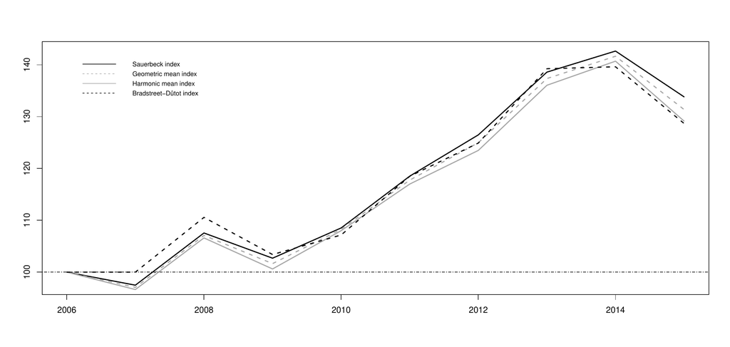

Figure 1: Joint evolution of the non-weighted complex price indexes in series for the unitary value of combustibles and energy resources for the main home in Spain from 2006 to 2015.

However, the variation of a given magnitude in time $t$ with respect to the previous period may also be of interest. Below, we alternatively enumerate the mathematical expressions of the previous indices based on index numbers in chain for the magnitudes.

- The *Carli index* (cf. (Carli 1804)) at time $t$ for X, $C^t(X)$, is calculated as the arithmetic mean of the simple index in chain for the $n$ involved magnitudes at $t$:
  $$\label{niCarli}C^t(X)=\frac{1}{n}\sum_{i=1}^n
  \frac{x_{it}}{x_{i t-1}}\cdot 100, \text{ for each t }\in\{1,\cdots,T\}.
  (\#eq:niCarli)$$
- The *Jevons index* at time $t$, $J^t(X)$, is calculated following (William Stanley Jevons 1863) as follows:
  $$\label{niJevons}J^t(X)=\sqrt[n]{\prod_{i=1}^n
  \frac{x_{it}}{x_{i t-1}}}\cdot 100,\text{ for each t
  }\in\{1,\cdots,T\}.
  (\#eq:niJevons)$$
  Given a collection of $n$ magnitudes, the geometric mean index at $t$ is obtained as $n^{th}$-root of the product of simple index numbers for $X$ in chain at time $t$.
- The *Dûtot index* at time $t$, $D^t(X)$, is introduced in (Dûtot 1754). Its value is obtained as the ratio between the means of the magnitude in time $t$ and the magnitude in time $t-1$ as follows:
  $$\label{niDutot}D^t(X)=\frac{\sum_{i=1}^n
  x_{it}}{\sum_{i=1}^n x_{i t-1}}\cdot 100,\text{ for each t
  }\in\{1,\cdots,T\}.
  (\#eq:niDutot)$$

Again, if $X$ denotes the matrix of prices of a set of goods or services along a period of time ($p$), these index numbers are named as the *Carli index* at time $t$ for prices, $C^t(p)$; the *Jevons index* at time $t$ for prices, $J^t(p)$; and the *Dûtot index* at time $t$ for prices, $D^t(p)$. To conclude this section, we obtain them for the set prices of combustibles and other energy resources for the main home in Spain from 2005 to 2015, detailed in Table 6. These index numbers are numerically detailed in Table 9.

Table 9: Non-weighted complex price indexes in chain for the unitary value of combustibles and energy resources for the main home in Spain from 2006 to 2015.

[output not shown]

All of the index numbers described are easy to be computed. However, they present an important disadvantage: they do not take into account the relative importance of each product.

### Weighted complex index numbers

For analyzing the evolution of a given magnitude $X$, it is very common to use an alternative magnitude $Y$ through the value of $Y$ in the reference or the actual period to weight complex index numbers. The information relative to this alternative variable can be summarized in a table such as Table 10. For instance, the use of the amount of production of different products or the use of prices may result of interest, depending on the setting under study.

Table 10: Evolution of a set of magnitudes $Y$ from time $0$ to $T$.

| Time Products | $1$ | $2$ | ... | $n$ |
| --- | --- | --- | --- | --- |
| 0 | $y_{10}$ | $y_{20}$ | ... | $y_{n0}$ |
| 1 | $y_{11}$ | $y_{21}$ | ... | $y_{n1}$ |
| $\vdots$ | $\vdots$ | $\vdots$ | $\vdots$ | $\vdots$ |
| $T$ | $y_{1T}$ | $y_{2T}$ | ... | $y_{nT}$ |

Next, the main weighted complex price index numbers for a given magnitude $X$, taking $Y$ as weight, are formally described:

- The *Laspeyres index* (K. Laspeyres 1871) analyzes the variations of $X$ using $Y$ as weight. In this sense, the weights considered for product $i$ are $x_{i0}\cdot y_{i0}$ (note that both values are referred to the base period). Then, this complex index is defined as the weighted arithmetic means of the simple index numbers:
  $$\label{niLaspeyres}
  L^t(X,Y)=\frac{\sum_{i=1}^n
  \frac{x_{it}}{x_{i0}}x_{i0}y_{i0}}{\sum_{i=1}^n x_{i0}y_{i0}}\cdot 100 =
  \frac{\sum_{i=1}^n x_{it}y_{i0}}{\sum_{i=1}^n x_{i0}y_{i0}}\cdot
  100,\text{ for each t }\in\{0,\cdots,T\}.
  (\#eq:niLaspeyres)$$
  The main disadvantage of the Laspeyres index is that it assumes that the weights do not vary in time. This hypothesis is not always realistic in some practical settings.
- The *Paasche index* is an alternative index to the Laspeyres index introduced in (Paasche 1874), when the weighted criteria is $x_{i0}\cdot y_{it}$. Therefore, it can be formally written as:
  $$\label{niPaasche}
  P^t(X,Y)=\frac{ \sum_{i=1}^n\frac{x_{it}}{x_{i0}}x_{i0}\cdot y_{it}
  }{\sum_{i=1}^n x_{i0}\cdot
  y_{it}}\cdot100= \frac{\sum_{i=1}^n x_{it}y_{it}}{\sum_{i=1}^n
  x_{i0}y_{it}}\cdot 100, \text{ for each t }\in\{0,\cdots,T\}.
  (\#eq:niPaasche)$$
- The *Marshall-Edgeworth index* (cf. (Marshall 1887), (Edgeworth 1887)) is an agregative weighted measure where weights are $y_{i0}+y_{it}$. Therefore, it can be calculated as:
  $$\label{niEdgeworth}
  E^t(X,Y)=\frac{\sum_{i=1}^n x_{it}(y_{i0}+y_{it})}{\sum_{i=1}^n
  x_{i0}(y_{i0}+y_{it}) }\cdot 100, \text{ for each t } \in\{0,\cdots,T\}.
  (\#eq:niEdgeworth)$$
- The *Fisher index* is equal to the geometric mean of the index numbers under the approaches of Laspeyres and Paasche:
  $$\label{niFisher}F^t(X,Y)=\sqrt{L^t(X,Y)\cdot
  P^t(X,Y)}, \text{ for each t }\in\{0,\cdots,T\}.
  (\#eq:niFisher)$$
  For instance, see more details in (Fisher 1922).

Note that other values can be defined (as we will see below). The choice of using a specific index formula often relies on the availability of data. According to the previous comments, the Laspeyres index does not require information on the products of the current period. Then, the Laspeyres formula is usually preferred for the calculation of complex indices, which are typically released rapidly before information for the current period could have been collected.

In what follows, $p$ denotes the matrix of prices of a set of goods or services along a period of time and $q$ is the matrix of the total amounts of goods in the same period. Thus, the *weighted complex price index numbers* analyze the time evolution of prices by introducing the variation of the physical production or the consumption of a set of goods or services. The weights are obtained by multiplying the price of a product in an instant of time $t$ by the consumption in the base period or the actual period. Hence, the *Laspeyres price index*, $L^t(p,q)$, the *Paasche price index*, $P^t(p,q)$, the *Marshall-Edgeworth price index*, $E^t(p,q)$, and the *Fisher price index*, $F^t(p,q)$, are naturally defined in prices settings.

Under this approach, a new complex index for $v$ can be naturally introduced under the approach of the Bradstreet-Dûtot index. It is based on the notion of the value of good indicated by $v$. It can be calculated as follows:
$$\label{nivalue}IV_{0}^t(p,q)=\frac{V_t(p,q)}{V_0(p,q)}=\frac{\sum_{i=1}^n
p_{it}q_{it} }{\sum_{i=1}^n p_{i0}q_{i0} }, \text{ for each t }
\in\{0,\cdots,T\}.
(\#eq:nivalue)$$
It satisfies that $IV_{0}^t(p,q)=L^t(p_0,q)\cdot P^t(p_0,q)=L^t(p,q_0)\cdot P^t(p,q_0)=F^t(p_0,q)\cdot F^t(p,q_0)$.

Table 11: Weighted complex price indexes for the unitary value of combustibles and energy resources for the main home in Spain from 2006 to 2015.

| $t$ | $L^t(p,q)$ | $P^t(p,q)$ | $E^t(p,q)$ | $F^t(p,q)$ | $IV_0^t(p,q)$ |
| --- | --- | --- | --- | --- | --- |
| 2006 | 100.00 | 100.00 | 100.00 | 100.00 | 100.00 |
| 2007 | 101.31 | 100.99 | 101.15 | 101.15 | 101.79 |
| 2008 | 110.23 | 109.89 | 110.06 | 110.06 | 115.89 |
| 2009 | 112.11 | 112.06 | 112.09 | 112.09 | 126.56 |
| 2010 | 115.76 | 116.69 | 116.27 | 116.22 | 144.02 |
| 2011 | 127.77 | 128.35 | 128.08 | 128.06 | 155.49 |
| 2012 | 142.72 | 143.32 | 143.04 | 143.02 | 168.01 |
| 2013 | 153.98 | 154.43 | 154.21 | 154.20 | 163.98 |
| 2014 | 158.54 | 158.62 | 158.58 | 158.58 | 154.09 |
| 2015 | 158.20 | 158.23 | 158.21 | 158.21 | 153.29 |

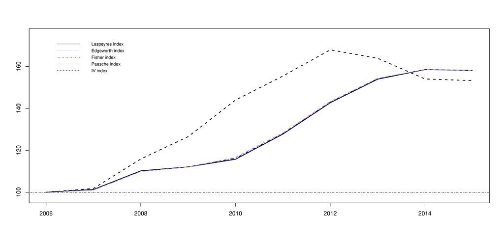

Figure 2: Joint evolution of the weighted complex price indexes for the unitary value of combustibles and energy resources for the main home in Spain from 2006 to 2015.

Otherwise, the *weighted complex production index numbers* analyze the time evolution of the amount of product by introducing the variation of the price of the goods or services as weight. Their obtaining is analogous to the previous one. The weights are obtained by multiplying the amount of a product in an instant of time $t$ by the prince in the base period or the actual period. Thus, we dealt with the *Laspeyres production index*, $L^t(q,p)$; the *Paasche production index*, $P^t(q,p)$; or the *Fisher production index* $F^t(q,p)$.

# IndexNumber in practice

This section presents an overview of the structure of the package. *IndexNumber* is a tool that R users can use in order to determine several classical index numbers that describe the evolution of a single magnitude or a set of magnitudes. This software helps the user to calculate faster these statistical measures. Functions in this library automatize the required operations for the computation of index numbers. First, we will describe the real data sets included in the package. Then, the functions implemented are detailed. Of course, other libraries exist in R dealing with index numbers theory. In particular, *micEconIndex* (Henningsen 2017), *IndexNumR* (White 2021), and *PriceIndices* (Bialek 2021) packages also allow to compute complex index numbers but only when the considered magnitudes are prices and quantities. It is worth mentioning that *IndexNumber* library was designed under a more general perspective by extending to any type of magnitude. Moreover, none of the above-referenced packages implement simple index numbers, and they do not offer graphical tools to facilitate the analysis of time evolution series either. Additionally, *IndexNumber* can be seen as an additional basic library that can also be exploited by non-experts R users. For instance, inputs of functions are numeric vectors or matrices containing the magnitude values, much more flexible than data structures that other packages consider. As for computational complexity, it is also relatively simple because, unlike *IndexNumR* that implements multilateral methods, the number of required elementary operations is smaller. Finally, it is convenient to note that *IndexNumber* package also provides four new recent real data sets.

## Data sets in IndexNumber

Index numbers have been theoretically introduced in previous sections using two real data sets included in the package *IndexNumber*. However, we decide to include them in the package because they could be used directly by the users, avoiding search and download. Besides, two additional data sets were also included. All of them are available in the website of the Spanish Statistical Office (INE), http://www.ine.es. These four data sets are briefly described below:

- Firstly, the data set `ActivePeople` was considered as an example in order to illustrate the simple index numbers. It contains information separately on the number (thousands) of economically active women and men in Spain from the first trimester in 2002 to the fourth one in 2019.
- Secondly, `ECResources` is a data set containing as variables, the unitary value (euros) and consumption (thousands of units) of several combustibles and other energy resources for the main home in Spain from 2006 to 2015. It was used in this paper for illustrating complex index numbers.
- An additional data set called `Mortgages` was also included in the package. In this case, the variables correspond to the number of mortgages constituted on urban properties in Spain from 2003 to 2018, distinguished between the kind of mortgages entities (banks, saving banks and other types). The corresponding mortgages amounts (thousands of euros) were also included as variables.
- Finally, the variables in the data set `Food` are the unitary value (euros) and consumed amount (thousands of units) of the main types of food in Spain from 2006 to 2015.

Once the package is installed and loaded, a full description of these data sets is shown through `help(ActivePeople)`, `help(ECResources)`, `help(Mortgages)`, and `help(Food)`, respectively.

## Functions in IndexNumber

*IndexNumber* package includes several functions that enable users to determine the index numbers, simple and complex (weighted and non-weighted), described in previous sections. The functions incorporated in the package are summarized in Table 12.

Table 12: Summary of functions in the *IndexNumber* package.

[output not shown]

Users can obtain different kinds of index numbers by introducing the associated parameters in the corresponding function. Table 13 describes the different options to determine those index numbers whose implementation was included in *IndexNumber* package. However, not all of the mentioned options are required since only some of them are specific for each particular class of index number. Thus, Table 14 summarizes the arguments associated with each function. Examples of usage for the implemented functions are described in the next section.

Table 13: Summary of arguments for functions in the *IndexNumber* package.

[output not shown]

Table 14: Arguments for each function in the *IndexNumber* package.

| Function | `x` | `y` | `base` | `type` | `name` | `opt.plot` | `opt.summary` |
| --- | --- | --- | --- | --- | --- | --- | --- |
| `aggregated.index.number` | $\checkmark$ | - | $\checkmark$ | $\checkmark$ | $\checkmark$ | $\checkmark$ | $\checkmark$ |
| `edgeworth.index.number` | $\checkmark$ | $\checkmark$ | - | - | $\checkmark$ | $\checkmark$ | $\checkmark$ |
| `fisher.index.number` | $\checkmark$ | $\checkmark$ | - | - | $\checkmark$ | $\checkmark$ | $\checkmark$ |
| `index.number.chain` | $\checkmark$ | - | - | - | $\checkmark$ | $\checkmark$ | $\checkmark$ |
| `index.number.serie` | $\checkmark$ | - | - | - | $\checkmark$ | $\checkmark$ | $\checkmark$ |
| `laspeyres.index.number` | $\checkmark$ | $\checkmark$ | - | - | $\checkmark$ | $\checkmark$ | $\checkmark$ |
| `paasche.index.number` | $\checkmark$ | $\checkmark$ | - | - | $\checkmark$ | $\checkmark$ | $\checkmark$ |

## Examples of using IndexNumber

In what follows, we describe several examples of the application of the *IndexNumber* package that is used to illustrate its performance. Initially, a user has to incorporate the package from the CRAN in the R Console. After its installation, the next code allows its usage:

```r
> library("IndexNumber")
```

Below, it is shown how to use the different functions implemented for determining index numbers on the real data sets presented in the preliminaries section.

### Simple index numbers in series in R

The example that we consider describes the obtaining of the simple index numbers in series (@ref(eq:niinserie)) in R software on the real data partially given in Table 1. Remember that it depicts the number (thousands) of economically active women and men in Spain. As we mentioned before, this information is also included in the data set `ActivePeople` in *IndexNumber* package. The first trimester of 2002 is considered as the reference value.

Using `index.numer.serie()` function, we obtain the simple index number in series for the first instants of time in the example.

```r
> index.number.serie(ActivePeople$TotalWomen[1:15],name="Woman",opt.plot=TRUE,
                     opt.summary = TRUE)

Index number in serie

Summary

Min.=101.855509425343

Stage=1

Max.=117.978690528975

Stage=13

$Summary
 Min. 1st Qu.  Median    Mean 3rd Qu.    Max.
101.9   106.1   110.4   110.3   114.6   118.0

$`Index number`
   Stages  Woman Index number
1       0 7442.7     100.0000
2       1 7580.8     101.8555
3       2 7670.2     103.0567
4       3 7751.5     104.1490
5       4 7868.7     105.7237
6       5 7977.8     107.1896
7       6 8093.3     108.7415
8       7 8190.9     110.0528
9       8 8249.7     110.8428
10      9 8348.9     112.1757
11     10 8430.8     113.2761
12     11 8564.6     115.0738
13     12 8635.2     116.0224
14     13 8780.8     117.9787
15     14 8769.1     117.8215
```

We include a graphical summary of the evolution of this magnitude under the fixed criteria in Figure 3, by using `opt.plot=TRUE`. We also summarize the most relevant information in terms of the instant in which the maximum and minimum values are reached choosing `opt.summary=TRUE`.

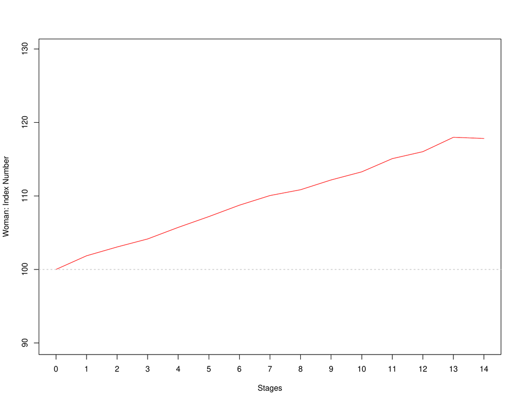

Figure 3: Evolution of the simple index number in series for the number (thousands) of economically active women in Spain.

Analogously, the user can obtain the corresponding results for the data associated to `TotalMen`. The required code in this case is the shown below:

```r
index.number.serie(ActivePeople$TotalMen[1:15],name="Man",opt.plot=TRUE,opt.summary = TRUE)
```

Results contained in Table 2 have been obtained using both functions of *IndexNumber* package in R.